# Fertilización nitrogenada y riego en el cultivo de papa

Propuesta de experimento agronómico | Programación – Unidad II

Autor/a

Lenin Mendoza Llanos

**NotaNaturaleza del trabajo**

Este documento presenta **una propuesta experimental**, no un ensayo ya ejecutado. El diseño, la aleatorización y los gráficos de planificación son reproducibles; **no se presentan rendimientos medidos ni se afirman efectos comprobados**.

# 1 Resumen del proyecto

Se propone evaluar, en el cultivo de papa (*Solanum tuberosum* L.), el efecto de tres dosis de fertilización nitrogenada (0, 100 y 200 kg N/ha) y dos intervalos de riego (7 y 14 días), mediante un **Diseño de Bloques Completos al Azar (DBCA)** con arreglo factorial 3 × 2 y cuatro bloques. El experimento tendrá seis tratamientos y 24 unidades experimentales. La variable respuesta principal será el rendimiento de tubérculos (t/ha). Se registrarán además características del crecimiento y de la producción.

Ficha resumen del experimento

| Indicador | Descripción |
| --- | --- |
| Cultivo | Papa (Solanum tuberosum L.) |
| Diseño | DBCA factorial 3 × 2 |
| Factores | Nitrógeno y frecuencia de riego |
| Tratamientos | 6 |
| Bloques | 4 |
| Unidades experimentales | 24 |
| Variable principal | Rendimiento (t/ha) |

# 2 Planteamiento del problema

La disponibilidad de nitrógeno favorece procesos como la formación de hojas y el crecimiento vegetal, mientras que el agua es necesaria para la fotosíntesis, el transporte de nutrientes y la formación de tubérculos. En campo, la aplicación de fertilizantes y la programación del riego pueden variar entre productores. Por ello, interesa evaluar **si las dosis de nitrógeno, la frecuencia de riego y su combinación** producen diferencias en el rendimiento de papa bajo las condiciones específicas del lugar de ensayo.

**Pregunta de investigación:** ¿Cómo influyen tres dosis de nitrógeno y dos frecuencias de riego en el rendimiento de tubérculos del cultivo de papa?

# 3 Objetivos e hipótesis

## 3.1 Objetivo general

Evaluar el efecto de la fertilización nitrogenada y de la frecuencia de riego sobre el rendimiento del cultivo de papa.

## 3.2 Objetivos específicos

1. Comparar el rendimiento de la papa bajo tres dosis de nitrógeno.
2. Evaluar la respuesta de la papa a dos intervalos de riego.
3. Determinar si existe interacción entre la dosis de nitrógeno y la frecuencia de riego.
4. Identificar las combinaciones de tratamientos con mejor desempeño, una vez obtenidos los datos de campo.

## 3.3 Hipótesis

- **Hipótesis nula (H₀):** las dosis de nitrógeno, las frecuencias de riego y su interacción no modifican el rendimiento promedio.
- **Hipótesis alternativa (H₁):** al menos uno de estos efectos modifica el rendimiento promedio.

# 4 Diseño experimental

## 4.1 Factores y niveles

Factores y niveles propuestos

| Factor | Niveles | Unidad |
| --- | --- | --- |
| A: Fertilización nitrogenada | 0, 100 y 200 | kg N/ha |
| B: Frecuencia de riego | 7 y 14 | días entre riegos |

Los tratamientos consisten en todas las combinaciones de ambos factores. Cada tratamiento aparecerá **una vez en cada bloque**, con aleatorización independiente dentro del bloque.

## 4.2 Tratamientos

Seis combinaciones factoriales

| Tratamiento | Nitrógeno (kg N/ha) | Intervalo de riego (días) |
| --- | --- | --- |
| T1 | 0 | 7 |
| T2 | 0 | 14 |
| T3 | 100 | 7 |
| T4 | 100 | 14 |
| T5 | 200 | 7 |
| T6 | 200 | 14 |

## 4.3 Unidad experimental y manejo

Cada unidad experimental será una parcela de papa. **Como propuesta inicial**, se plantea una parcela de 2 m × 3 m (6 m²), cuya dimensión deberá ajustarse a la disponibilidad de terreno, distanciamiento de siembra y bordes de cosecha. Si se utiliza esa dimensión, las 24 parcelas abarcarán 144 m² netos, **sin incluir caminos ni separación entre bloques**.

Para que la comparación sea válida, se mantendrán constantes la variedad de papa, la procedencia y calidad de la semilla, la fecha de siembra, el manejo fitosanitario y, en lo posible, otras prácticas agronómicas. El aporte de fósforo y potasio se definirá de acuerdo con el análisis de suelo. Las dosis de nitrógeno deberán calcularse según la riqueza del fertilizante utilizado.

**AdvertenciaConsideración importante sobre el riego**

El intervalo de 7 o 14 días no describe por sí solo la cantidad de agua aplicada. En el protocolo definitivo deben registrarse **volumen o lámina por riego, lluvias y humedad del suelo**, porque la respuesta de la papa depende también del suministro hídrico total.

# 5 Libro de campo y croquis

## 5.1 Aleatorización reproducible

El siguiente bloque crea un libro de campo con **24 parcelas**. La semilla `2026` permite reproducir exactamente la misma asignación en sucesivos Render.

**Ver código en R**

```r
set.seed(2026)
tratamientos <- data.frame(
  tratamiento = paste0("T", 1:6),
  nitrogeno = c(0, 0, 100, 100, 200, 200),
  riego = c(7, 14, 7, 14, 7, 14)
)
fb <- do.call(rbind, lapply(1:4, function(b) {
  orden <- sample(1:6)
  data.frame(
    bloque = b,
    parcela = 1:6,
    tratamientos[orden, ],
    row.names = NULL
  )
}))
fb$codigo <- sprintf("B%d-P%02d", fb$bloque, fb$parcela)
fb <- fb[, c("codigo", "bloque", "parcela", "tratamiento", "nitrogeno", "riego")]
knitr::kable(fb, caption = "Libro de campo del experimento de papa")
```

Libro de campo del experimento de papa

| codigo | bloque | parcela | tratamiento | nitrogeno | riego |
| --- | --- | --- | --- | --- | --- |
| B1-P01 | 1 | 1 | T5 | 200 | 7 |
| B1-P02 | 1 | 2 | T1 | 0 | 7 |
| B1-P03 | 1 | 3 | T6 | 200 | 14 |
| B1-P04 | 1 | 4 | T2 | 0 | 14 |
| B1-P05 | 1 | 5 | T4 | 100 | 14 |
| B1-P06 | 1 | 6 | T3 | 100 | 7 |
| B2-P01 | 2 | 1 | T3 | 100 | 7 |
| B2-P02 | 2 | 2 | T4 | 100 | 14 |
| B2-P03 | 2 | 3 | T5 | 200 | 7 |
| B2-P04 | 2 | 4 | T1 | 0 | 7 |
| B2-P05 | 2 | 5 | T6 | 200 | 14 |
| B2-P06 | 2 | 6 | T2 | 0 | 14 |
| B3-P01 | 3 | 1 | T2 | 0 | 14 |
| B3-P02 | 3 | 2 | T6 | 200 | 14 |
| B3-P03 | 3 | 3 | T4 | 100 | 14 |
| B3-P04 | 3 | 4 | T3 | 100 | 7 |
| B3-P05 | 3 | 5 | T1 | 0 | 7 |
| B3-P06 | 3 | 6 | T5 | 200 | 7 |
| B4-P01 | 4 | 1 | T6 | 200 | 14 |
| B4-P02 | 4 | 2 | T1 | 0 | 7 |
| B4-P03 | 4 | 3 | T4 | 100 | 14 |
| B4-P04 | 4 | 4 | T2 | 0 | 14 |
| B4-P05 | 4 | 5 | T3 | 100 | 7 |
| B4-P06 | 4 | 6 | T5 | 200 | 7 |

## 5.2 Croquis experimental por bloques

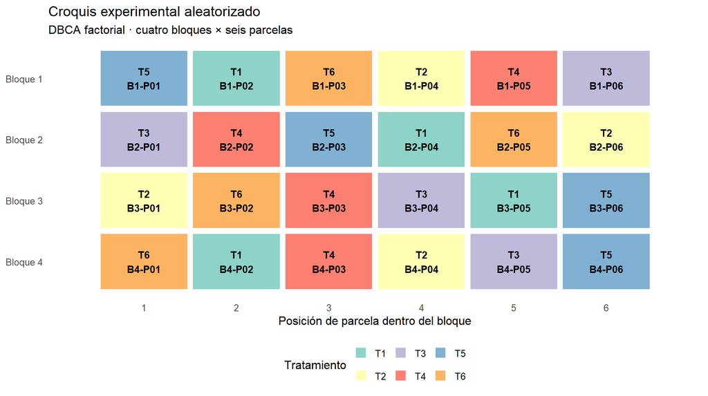

## 5.3 Matriz de distribución de tratamientos

Tratamientos asignados por bloque y parcela

|  | Parcela 1 | Parcela 2 | Parcela 3 | Parcela 4 | Parcela 5 | Parcela 6 |
| --- | --- | --- | --- | --- | --- | --- |
| Bloque 1 | T5 | T1 | T6 | T2 | T4 | T3 |
| Bloque 2 | T3 | T4 | T5 | T1 | T6 | T2 |
| Bloque 3 | T2 | T6 | T4 | T3 | T1 | T5 |
| Bloque 4 | T6 | T1 | T4 | T2 | T3 | T5 |

# 6 Gráficos de planificación

## 6.1 Dosis de nitrógeno por tratamiento

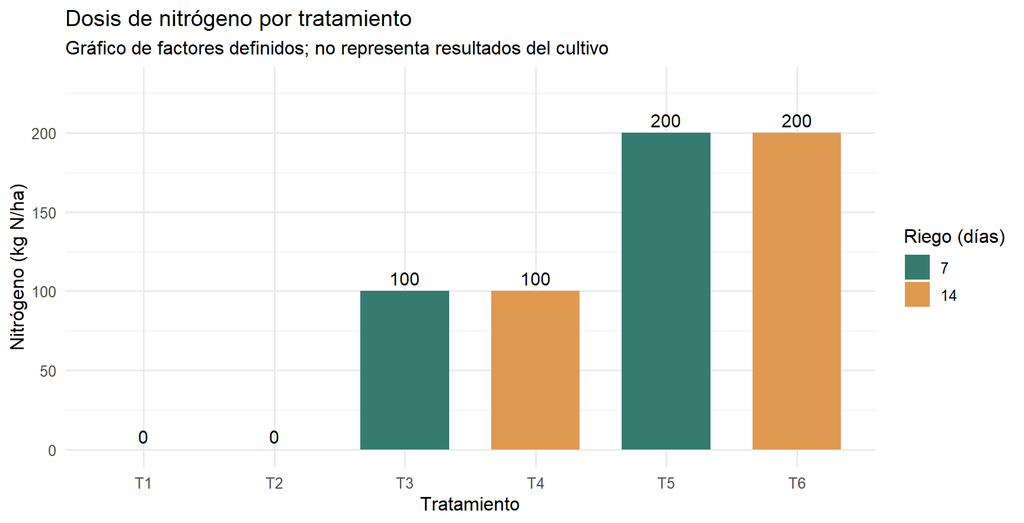

## 6.2 Estructura factorial del estudio

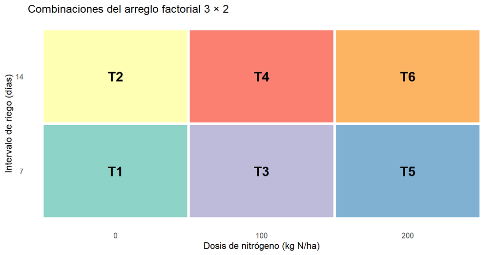

# 7 Variables y toma de datos

| Variable | Unidad | Procedimiento propuesto |
| --- | --- | --- |
| Altura de planta | cm | Medir desde la base hasta el extremo superior de la planta seleccionada. |
| Número de tallos | tallos/planta | Contar tallos principales en plantas marcadas. |
| Número de tubérculos | tubérculos/planta | Contar al momento de la cosecha. |
| Peso de tubérculos | kg/planta | Pesar los tubérculos obtenidos de las plantas evaluadas. |
| Rendimiento | t/ha | Pesar la producción del área útil y convertirla a hectárea. |

Para cada parcela se recomienda registrar fecha de siembra, fecha de evaluación, tratamientos aplicados, lluvias, lámina de riego, observaciones sanitarias y área efectiva cosechada. Las mediciones deben realizarse con el mismo procedimiento en todas las parcelas.

## 7.1 Conversión del rendimiento

Esta expresión se utilizará cuando se disponga de los pesos reales de cosecha.

# 8 Plan de análisis estadístico

Al finalizar el ensayo se realizará un ANOVA factorial en DBCA. Antes de interpretar los resultados, se revisarán los supuestos del modelo mediante el análisis de residuos y la homogeneidad de varianzas. Si la interacción nitrógeno × riego es significativa, se compararán las combinaciones de tratamientos, por ejemplo con medias marginales estimadas y ajuste de Tukey al 5 %. Si no es significativa, se podrán interpretar los efectos principales con el cuidado correspondiente.

**Ver código en R**

```r
# Este bloque es una plantilla: NO ejecutarlo sin datos reales.
# datos_reales <- read.csv("datos_papa.csv")
# datos_reales$bloque <- factor(datos_reales$bloque)
# datos_reales$nitrogeno <- factor(datos_reales$nitrogeno)
# datos_reales$riego <- factor(datos_reales$riego)
# md <- aov(rendimiento_t_ha ~ bloque + nitrogeno * riego,
#           data = datos_reales)
# summary(md)
# library(emmeans)
# emmeans(md, ~ nitrogeno * riego)
```

# 9 Resultados esperados y limitaciones

Se espera que los tratamientos produzcan respuestas distintas en crecimiento o rendimiento, pero **no es posible anticipar cuál será superior sin medir las parcelas**. Los resultados estarán condicionados por la fertilidad del suelo, la variedad, el clima, el manejo del agua y otros factores locales. La superficie propuesta y los intervalos de riego deberán validarse antes de instalar el ensayo.

# 10 Conclusiones de la propuesta

La propuesta organiza un experimento factorial de dos factores con seis tratamientos y cuatro bloques, para un total de 24 unidades experimentales. El libro de campo, el croquis y los gráficos presentados describen **la planificación**. Cuando se realice la cosecha y se registren los datos, será posible evaluar estadísticamente el rendimiento y sustentar conclusiones experimentales.

# 11 Referencias de consulta

- Documentación de Quarto: https://quarto.org/docs/guide/
- Documentación de R: https://www.r-project.org/
- Documentación de ggplot2: https://ggplot2.tidyverse.org/